# Pobieranie danych z Internetu

Przemysław Biecek

R i Duże Dane

# Intro

Duże dane najczęściej są generowane strumieniowo, przykładowo:

- wielkie maszyny w kopalniach z setkami czujników, monitorujących ich działanie (predictive maintenance),
- monitoring transakcji bankowych (fraud detection),
- dane z serwisów społecznościowych,
- logi ruchu sieciowego,
- scapping stron internetowych,
- i wiele innych.

# Intro

Dostęp do tych danych jest możliwy na różne sposoby, trzy najczęstsze to:

- dostęp do plików tekstowych lub bazy danych z danymi,
- dostęp zapewniony przez dostawcę danych: API (Application Programming Onterface), często typu REST (Representational State Transfer),
- zbieranie skrawków danych na własną rękę, jeżeli dane są publicznie dostępne ale nie są w strukturze łatwej do dalszego przetwarzania.

Dziś i za tydzień omówimy przykłady obu sposobów na pozyskanie danych.

# Bezpośrednie odczytanie danych z Internetu

Dane są dostępne w Internecie w strukturze tabelarycznej nie wymagającej dalszego przetwarzania.

```r
# Ranking uczelni według Polityki
dane <- read.table("http://tofesi.mimuw.edu.pl/~cogito/smarterpoland/rankingUczelni2011/RankingUczelni2011.csv",
                   sep=";", skip=1, header=TRUE)
head(dane)
```

```
##     Miasto                 Typ.Uczelni                     Reszta.Nazwy
## 1 Warszawa                 Uniwersytet                       Warszawski
## 2   Krakow                 Uniwersytet                     Jagiellonski
## 3 Warszawa                Politechnika                       Warszawska
## 4   Poznan                 Uniwersytet im. Adama Mickiewicza w Poznaniu
## 5  Wroclaw                Politechnika                       Wroclawska
## 6   Krakow Akademia Gorniczo-Hutnicza                        w Krakowie
##   ranking.2011 ranking.2010 ranking.2009 ranking.2008 suma.punktow
## 1            1            1            2            2       100.00
## 2            2            2            1            1        99.71
## 3            3            4            4            5        85.52
## 4            4            3            3            4        76.38
## 5            5            5            6            7        75.91
## 6            6            7            5            8        75.35
##   preferencje.pracodawcow ocena.kadry.akademickiej uznanie.miedzynarodowe
```

[output cut: 76 more lines]

# Bezpośrednie odczytanie danych z Internetu

Dane nie mają struktury i takimi je chcemy odczytać.

```r
# http://www.gutenberg.org/ebooks/103
# http://www.gutenberg.org/cache/epub/103/pg103.txt

# W 80 dni dookoła świata
w80dni <- readLines("http://www.gutenberg.org/cache/epub/103/pg103.txt")

# Kilka pierwszych linii
head(w80dni)
```

```
## [1] "The Project Gutenberg EBook of Around the World in 80 Days, by Jules Verne"
## [2] ""
## [3] "This eBook is for the use of anyone anywhere at no cost and with"
## [4] "almost no restrictions whatsoever.  You may copy it, give it away or"
## [5] "re-use it under the terms of the Project Gutenberg License included"
## [6] "with this eBook or online at www.gutenberg.net"
```

```r
# rozbicie linii na słowa
slowa <- unlist(strsplit(w80dni, split="[^A-Za-z0-9]+"))
# liczba słów i charakterystyki
length(slowa)
```

```
## [1] 68460
```

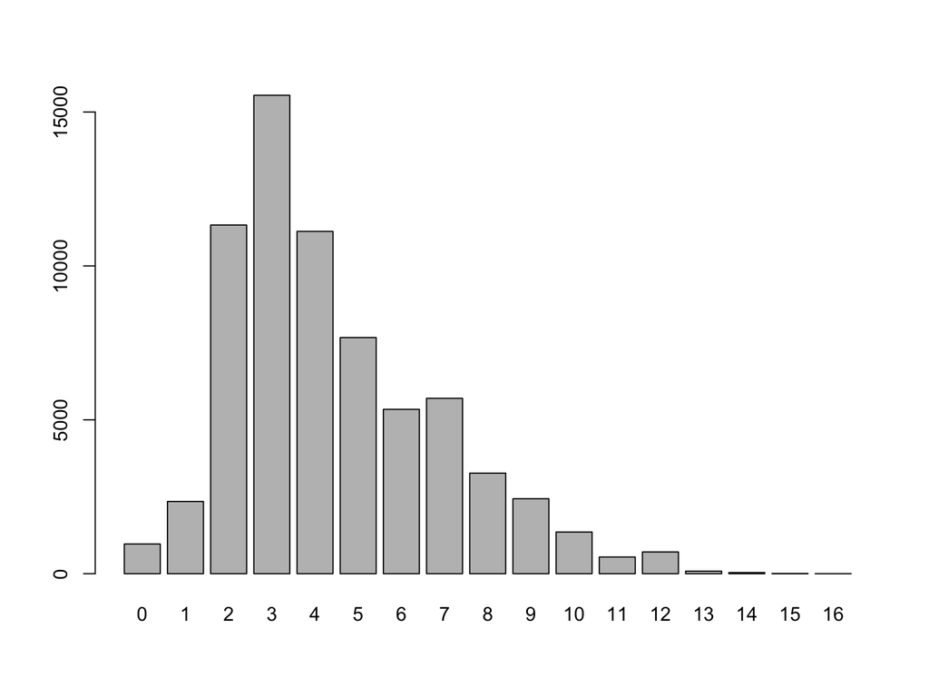

```r
barplot(table(nchar(slowa)))
```

```r
head(sort(table(slowa), decreasing = TRUE), 20)
```

```
## slowa
##   the   and    of    to     a    in   was         his    he  Fogg    at
##  4312  1896  1876  1720  1281   997   995   966   807   773   608   583
##  with   not   The  that    on   had which   for
##   553   519   518   514   504   494   442   433
```

# Parsowanie stroni HTML

Dane mają strukturę ale aby je wyłuskać wymaga to trochę pracy [i znajomosci wyrażeń regularnych]

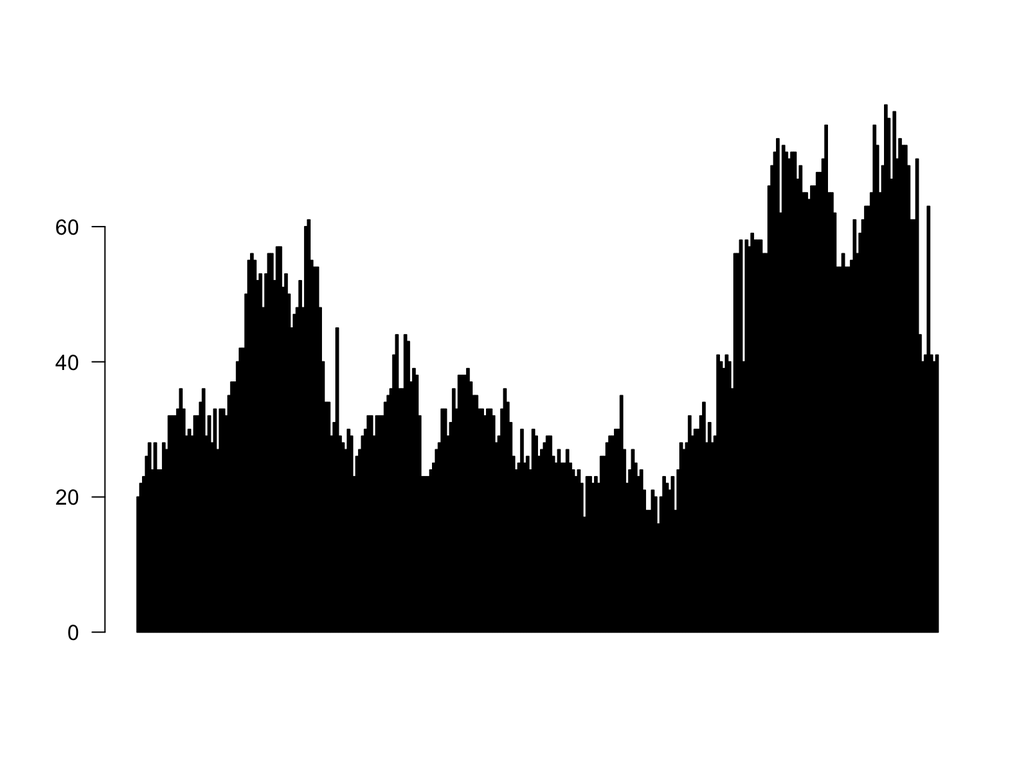

```r
# Odczytanie treści strony www
html <- readLines("http://pl.wikipedia.org/wiki/Reprezentacja_Polski_w_pi%C5%82ce_no%C5%BCnej")
html <- paste(html, collapse="")

# Wydzieramy dane łyżeczką
tmp1 <- strsplit(html, split="Reprezentacja Polski w Rankingu FIFA")[[1]][5]
tmp2 <- strsplit(tmp1, split="najlepsze miejsce")[[1]][1]
tmp3 <- strsplit(tmp2, split="<[^>]+>")[[1]]
wartosci <- na.omit(as.numeric(tmp3))

# i rysunek pozycji reprezentajci Polski w rankingu FIFA
barplot(wartosci[wartosci < 1000], las=1, col="black")
```

# Parsowanie stroni HTML z użyciem pakietu XML

Aby nie parsować strony HTML ręcznie za każdym razem dostępnych jest wiele narzędzi, robiących parsowanie za nas.

Pakiet `XML` zawiera funkcję `readHTMLTable()` wyszukującą wszystkie tabele oraz konwertującą je do ramek danych w R.

```r
# http://pl.wikipedia.org/wiki/Reprezentacja_Polski_w_pi%C5%82ce_no%C5%BCnej
library(XML)
html <- "http://pl.wikipedia.org/wiki/Reprezentacja_Polski_w_pi%C5%82ce_no%C5%BCnej"
tabele <- readHTMLTable(html, stringsAsFactors = FALSE)
# Tabel jest dużo, a ta której szukamy jest akurat 19
zwyciestwa <- tabele[[19]]

library(dplyr)
zwyciestwa$ProcentZwyciestw <- as.numeric(as.character(zwyciestwa[,2])) /
                                 as.numeric(as.character(zwyciestwa[,5]))
arrange(zwyciestwa, ProcentZwyciestw)
```

```
##                          Rywale Zwycięstwa Remisy Porażki Razem
## 1                     Australia          0      0       1     1
## 2                    Czarnogóra          0      2       0     2
## 3                         Egipt          0      1       1     2
## 4                       Kamerun          0      2       1     3
## 5              Korea Południowa          0      1       1     2
## 6                          Kuba          0      1       0     1
## 7                      Paragwaj          0      0       1     1
## 8                        Anglia          1      7      11    19
## 9                        Niemcy          1      6      12    19
## 10                     Brazylia          1      2       9    12
## 11                    Hiszpania          1      1       8    10
## 12                      Rumunia          4     15      14    33
## 13                      Francja          3      5       8    16
## 14                    Chorwacja          1      1       3     5
```

[output cut: 179 more lines]

# Parsowanie stroni HTML z pakietem rvest

Jeżeli dane nie są w postaci tabelarycznej, bardzo wygodną biblioteką do pracy z danymi jest `rvest`.

Użyteczne funkcje:

- html - tworzy strukturę drzewiastą html
- html_nodes - wyszukuje węzły w drzewie pasujące do określonego wzorca
- html_text, html_tag, html_attrs - wyciąga treść lub atrybuty węzłów html.

```r
library(rvest)
gazeta <- html("http://gazeta.pl")
cast <- html_nodes(gazeta, "span.title")
html_text(cast)
```

```
##   [1] "Pogoda"
##   [2] "Ukraina nie wykorzystuje swojego potencjału na wojnie? \"Poroszenko przyjął błędną taktykę\""
##   [3] "\"Chodź, szogunie!\" to nie wpadka? MSZ wydało oświadczenie ws. wizyty Komorowskiego w Japonii"
##   [4] "Pogrzeb. Do opozycyjnej dziennikarki podchodzi nieznajomy. \"Będzie pani następna\""
##   [5] "Afera wokół restauracji Basi Ritz. Ośmiornicą o mur? \"To nieludzkie, co na to sanepid?\""
##   [6] "\"HTC Vive to nie jest pierwsze urządzenie tego typu, ale pierwsze, wobec którego ogłaszane są tak poważne plany\""
##   [7] "Szkielety przytulają się i całują, a gdy wyjdą zza ekranu, brawa! Dlaczego?"
##   [8] "Polska w czołówce. Masowo ściągamy najnowszy sezon \"HoC\""
##   [9] "ALERT24 605 24 24 24"
##  [10] "\"Dajcie nam, rodzicom, wybór. Nie prosimy o przywileje, nie prosimy o pieniądze\". Głosowanie jutro"
##  [11] "Jest wielu ochotników do służby przygotowawczej w wojsku. \"Zgłaszają się nawet osoby po sześćdziesiątce\""
##  [12] "\"Kaczyński zachwycony kampanią. Kandydat Duda z podwojonym budżetem\""
##  [13] "\"Ukraińców żal, a najemnicy z Polski? Przyjechali tu...\""
##  [14] "Jest CD, a na nim 11 nowych nagrań polskich polityków"
##  [15] "Sąd: Policjant, który zastrzelił Browna, nie złamał prawa"
```

[output cut: 160 more lines]

# Jak znajdować uchwyty CSS

Używając gadgetSeelctor można łatwo określić ścieżkę wyszukiwania w drzewie html.

```r
oskary <- html("http://www.filmweb.pl/oscary")
filmy <- html_nodes(oskary, "#awardYearList .sep-comma a")
html_text(filmy)
```

```
##  [1] "Birdman"
##  [2] "Zniewolony. 12 Years a Slave"
##  [3] "Operacja Argo"
##  [4] "Artysta"
##  [5] "Jak zostać królem"
##  [6] "The Hurt Locker. W pułapce wojny"
##  [7] "Slumdog. Milioner z ulicy"
##  [8] "To nie jest kraj dla starych ludzi"
##  [9] "Infiltracja"
## [10] "Miasto gniewu"
## [11] "Za wszelką cenę"
## [12] "Władca Pierścieni: Powrót króla"
## [13] "Chicago"
## [14] "Piękny umysł"
## [15] "Gladiator"
```

[output cut: 72 more lines]

Pakiet `rvest` pozwala też na parsowanie tabel oraz na obsługę formularzy, sesji i śledzenie linków.

```r
lego_movie <- html("http://www.imdb.com/title/tt1490017/")

htab <- html_nodes(lego_movie, "table")[[3]]
html_table(htab)
```

```
##                                                           X1
## 1                        Oscars: Are You *Bleep* Kidding Me?
## 2                                    Why Didn't You Like It?
## 3                                            Favourite line?
## 4 Variety: 5 Reasons the Academy Overlooked "The LEGO Movie"
## 5                                                    Snubbed
## 6                                             Academy Awards
##                  X2
## 1         nexuswolf
## 2         mball1297
## 3          haze_419
## 4 CorporalCormorant
## 5         MrBean505
## 6       browncoatjw
```

# API bez autoryzacji

Fundacja MojePanstwo udostępnia API dzieki któremu można automatycznie pobrać dane w formacie JSON.

Między innymi udostępnia kopię Banku Danych Lokalnych. Poleceniem `search` można wyszukiwać tabele z odpowiednimi danymi.

http://api.mojepanstwo.pl/bdl/search?q=bezrobocie

```r
url <- 'http://api.mojepanstwo.pl/bdl/search?q=bezrobocie'
document <- rjson::fromJSON(file=url, method='C')

tematy <- sapply(document, function(x) x$data$bdl_wskazniki.tytul)
kody <- sapply(document, function(x) x$data$bdl_wskazniki.id)
cbind(tematy, kody)
```

```
##       tematy
##  [1,] NULL
##  [2,] "Stopa bezrobocia rejestrowanego"
##  [3,] "Bezrobotni zarejestrowani wg płci"
##  [4,] "Udział bezrobotnych zarejestrowanych w liczbie ludności w wieku produkcyjnym wg wykształcenia"
##  [5,] "Stopa bezrobocia wg poziomu wykształcenia"
##  [6,] "Niepełnosprawni zarejestrowani w urzędzie pracy wg płci"
##  [7,] "Stopa bezrobocia wg miejsca zamieszkania"
##  [8,] "Oferty pracy wg grup osób"
##  [9,] "Udział zarejestrowanych bezrobotnych absolwentów wśród bezrobotnych ogółem wg płci"
## [10,] "Udział bezrobotnych zarejestrowanych w liczbie ludności w wieku produkcyjnym wg płci"
##       kody
##  [1,] NULL
##  [2,] "776"
##  [3,] "763"
##  [4,] "41163"
##  [5,] "41319"
##  [6,] "40143"
##  [7,] "745"
##  [8,] "775"
##  [9,] "41164"
## [10,] "779"
```

# API bez autoryzacji

Poleceniem `series` można pobierać dane o określonej serii danych.

http://api.mojepanstwo.pl/bdl/series?metric_id=776

```r
url <- "http://api.mojepanstwo.pl/bdl/series?metric_id=776"
document <- rjson::fromJSON(file=url, method='C')

lista <- document[[1]][[1]]$series
vrok <- sapply(lista, function(x) x$year)
vwal <- sapply(lista, function(x) x$value)
cbind(vrok, vwal)
```

```
##       vrok   vwal
##  [1,] "2004" "19.00"
##  [2,] "2005" "17.60"
##  [3,] "2006" "14.80"
##  [4,] "2007" "11.20"
##  [5,] "2008" "9.50"
##  [6,] "2009" "12.10"
##  [7,] "2010" "12.40"
##  [8,] "2011" "12.50"
##  [9,] "2012" "13.40"
## [10,] "2013" "13.40"
```

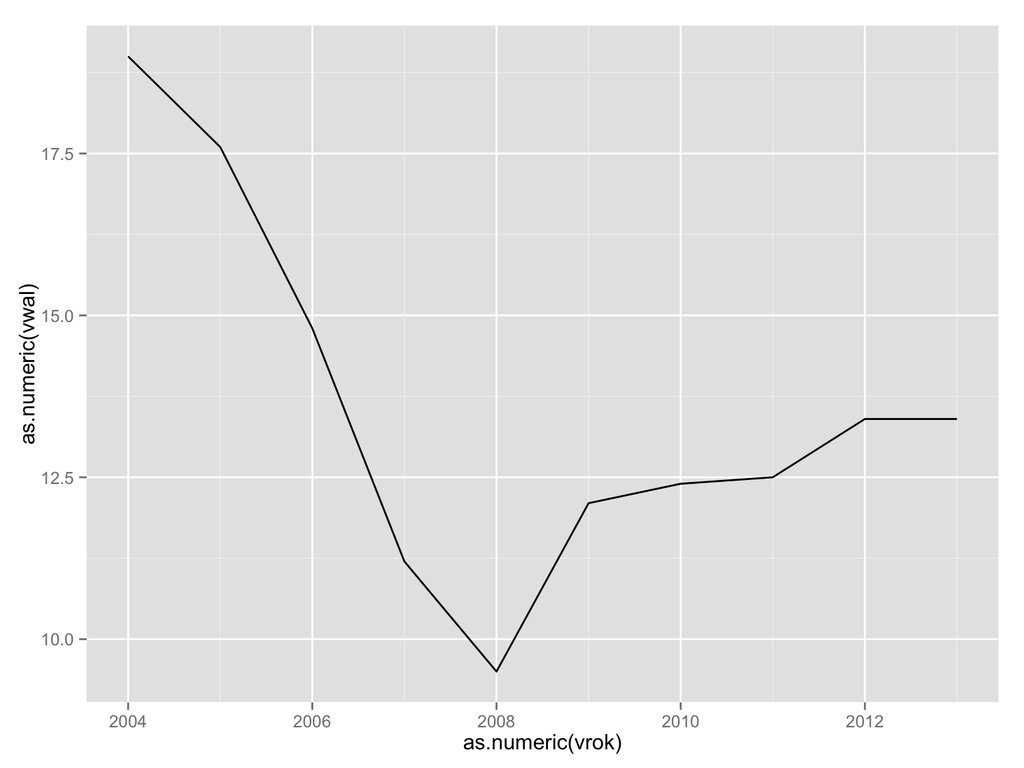

```r
library(ggplot2)
qplot(as.numeric(vrok), as.numeric(vwal), geom="line")
```